# df_bisnode_final

### PADS Predicao de Falencia de empresas

##### Por Jefferson Ramos, Alex Mondl e Flavia Sousa

##### -- Ferramentas utilizadas: VS Code, Jupyter Notebook, Pycharm e R Studio

##### -- Dataframe: cs_bisnode_panel

##### Importando libraries para modelagem

```python
import pandas as pd
import matplotlib.pyplot as plt
import seaborn as sns
import numpy as np
import missingno as msno
import altair as alt
from matplotlib import rcParams
# !pip install altair
```

#### Importando o dataset

```python
df = pd.read_csv('C:/Users/Jeffs/Documents/PADS Insper/PROJETO INTEGRADOR/cs_bisnode_panel.csv')
```

#### Checando qty de linhas e colunas do dataframe `cs_bisnode`

```python
df.shape #total de linhas, total de colunas
```

```
(287829, 48)
```

```python
#Quantas linhas e colunas (variáveis) temos no dataframe
# identificar o volume de dados do DataFrame:
# shape[0] = #registros
# shape[1] = #variáveis

print("# Registros:\t{}".format(df.shape[0]))
print("# Variáveis:\t{}\n".format(df.shape[1]))

#Quais os tipos das variáveis?
display(df.dtypes)
```

```
# Registros:	287829
# Variáveis:	48
```

```
comp_id                 float64
begin                    object
end                      object
COGS                    float64
amort                   float64
curr_assets             float64
curr_liab               float64
extra_exp               float64
extra_inc               float64
extra_profit_loss       float64
finished_prod           float64
fixed_assets            float64
inc_bef_tax             float64
intang_assets           float64
inventories             float64
liq_assets              float64
material_exp            float64
net_dom_sales           float64
net_exp_sales           float64
personnel_exp           float64
profit_loss_year        float64
sales                   float64
share_eq                float64
subscribed_cap          float64
tang_assets             float64
wages                   float64
D                       float64
balsheet_flag             int64
balsheet_length           int64
balsheet_notfullyear      int64
year                      int64
founded_year            float64
exit_year               float64
ceo_count               float64
foreign                 float64
female                  float64
birth_year              float64
inoffice_days           float64
gender                   object
origin                   object
nace_main               float64
ind2                    float64
ind                     float64
urban_m                   int64
region_m                 object
founded_date             object
exit_date                object
labor_avg               float64
dtype: object
```

#### Filtrando e excluindo

```python
# excluir colunas especificadas no doc
df = df.drop(['COGS', 'finished_prod', 'net_dom_sales', 'net_exp_sales', 'wages', 'D'], axis=1)
# apos o drop, teremos consequentemente menos colunas
```

```python
# checar se há linhas duplicadas
df.duplicated().astype(int).sum()
# há zero linhas duplicadas
```

```
0
```

```python
df = df.query('year != 2016') # filtrando para remover das observacoes o ano `2016`` conforme solicitado no doc
```

```python
#Visualizando as 5 primeiras linhas do dataset para analisar se filtro foi aplicado, existencia de NaN, 0, Missing Values, etc
df.head()
```

|  | comp_id | begin | end | amort | curr_assets | curr_liab | extra_exp | extra_inc | extra_profit_loss | fixed_assets | ... | gender | origin | nace_main | ind2 | ind | urban_m | region_m | founded_date | exit_date | labor_avg |
| --- | --- | --- | --- | --- | --- | --- | --- | --- | --- | --- | --- | --- | --- | --- | --- | --- | --- | --- | --- | --- | --- |
| 0 | 1001034.0 | 2005-01-01 | 2005-12-31 | 692.592590 | 7266.666504 | 7574.074219 | 0.0 | 0.0 | 0.0 | 1229.629639 | ... | mix | Domestic | 5630.0 | 56.0 | 3.0 | 1 | Central | 1990-11-19 | NaN | NaN |
| 1 | 1001034.0 | 2006-01-01 | 2006-12-31 | 603.703674 | 13122.222656 | 12211.111328 | 0.0 | 0.0 | 0.0 | 725.925903 | ... | mix | Domestic | 5630.0 | 56.0 | 3.0 | 1 | Central | 1990-11-19 | NaN | NaN |
| 2 | 1001034.0 | 2007-01-01 | 2007-12-31 | 425.925934 | 8196.295898 | 7800.000000 | 0.0 | 0.0 | 0.0 | 1322.222168 | ... | mix | Domestic | 5630.0 | 56.0 | 3.0 | 1 | Central | 1990-11-19 | NaN | NaN |
| 3 | 1001034.0 | 2008-01-01 | 2008-12-31 | 300.000000 | 8485.185547 | 7781.481445 | 0.0 | 0.0 | 0.0 | 1022.222229 | ... | mix | Domestic | 5630.0 | 56.0 | 3.0 | 1 | Central | 1990-11-19 | NaN | NaN |
| 4 | 1001034.0 | 2009-01-01 | 2009-12-31 | 207.407410 | 5137.037109 | 15300.000000 | 0.0 | 0.0 | 0.0 | 814.814819 | ... | mix | Domestic | 5630.0 | 56.0 | 3.0 | 1 | Central | 1990-11-19 | NaN | 0.083333 |

5 rows × 42 columns

#### Obs por `year`

```python
df['year'].value_counts()
```

[output not shown]

#### Analisando Missings

##### Qual a porcentagem de valores ausentes/faltantes no dataset (missings)?

```python
# ordenar em ordem decrescente as variáveis por seus valores ausentes
(df.isnull().sum() / df.shape[0]).sort_values(ascending=False)
```

```
exit_year               0.860266
exit_date               0.797983
labor_avg               0.526754
birth_year              0.397564
founded_year            0.202017
gender                  0.201909
origin                  0.201909
female                  0.201909
foreign                 0.201909
ceo_count               0.201909
inoffice_days           0.201909
ind                     0.034061
extra_exp               0.031595
extra_inc               0.031595
material_exp            0.028826
personnel_exp           0.028826
amort                   0.028826
extra_profit_loss       0.026826
sales                   0.026744
inc_bef_tax             0.026744
tang_assets             0.005286
ind2                    0.003733
nace_main               0.003733
region_m                0.002877
profit_loss_year        0.000507
intang_assets           0.000503
subscribed_cap          0.000471
share_eq                0.000471
liq_assets              0.000471
inventories             0.000471
fixed_assets            0.000471
curr_liab               0.000471
curr_assets             0.000471
founded_date            0.000183
urban_m                 0.000000
comp_id                 0.000000
year                    0.000000
balsheet_notfullyear    0.000000
balsheet_length         0.000000
begin                   0.000000
end                     0.000000
balsheet_flag           0.000000
dtype: float64
```

```python
df = df.drop(['birth_year','exit_date', 'exit_year','labor_avg', 'female', 'foreign', 'nace_main', 'ind'], axis=1)
```

#### Obs da linha anterior

- *as variáveis exit_date, exit_year e birth_year apresentam enorme quantidade de missings, sendo excluídas, uma vez que a mera ocorrência de receita em um ano é mais relevante do que a indicação de exit*  
- *as variáveis labor_avg e birth_year, pela grande quantidade de missings, também serão excluídas*  
- *todas as outras estão sendo excluídas por não serem relevantes para a análise e por conterem idogeneidade*

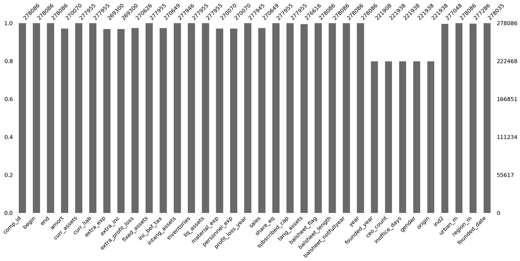

```python
msno.bar(df) #checando missings através de gráfico de barras
```

##### constatado com `msno.bar` ser necessario uma melhor limpeza de dados de colunas com missings

#### Checando variáveis que serão utilizadas e seus tipos

```python
# checando o tipo de cada variável
df.dtypes
```

```
comp_id                 float64
begin                    object
end                      object
amort                   float64
curr_assets             float64
curr_liab               float64
extra_exp               float64
extra_inc               float64
extra_profit_loss       float64
fixed_assets            float64
inc_bef_tax             float64
intang_assets           float64
inventories             float64
liq_assets              float64
material_exp            float64
personnel_exp           float64
profit_loss_year        float64
sales                   float64
share_eq                float64
subscribed_cap          float64
tang_assets             float64
balsheet_flag             int64
balsheet_length           int64
balsheet_notfullyear      int64
year                      int64
founded_year            float64
ceo_count               float64
inoffice_days           float64
gender                   object
origin                   object
ind2                    float64
urban_m                   int64
region_m                 object
founded_date             object
dtype: object
```

### Tipo de industria mais relevante no DF?

```python
df['ind2'].value_counts() # checando a frequencia de cada valor da variavel ind2
```

```
56.0    160629
55.0     32781
28.0     24830
33.0     20840
26.0     14289
         ...
20.0         6
35.0         5
88.0         5
24.0         4
17.0         4
Name: ind2, Length: 68, dtype: int64
```

### Tratamento com drops, missings, NaN e 0

##### - a variável founded_year apresenta formatação incorreta e menos observações do que founded_date

##### - founded_year será substituída por founded_date transformada em sua contraparte anual

```python
df['founded_year'].dtypes
df['founded_year'].values
```

```
array([1990., 1990., 1990., ...,   nan, 1990., 1990.])
```

##### drop de coluna founded_year. Coluna já foi incorporada por outra variavel criada.

```python
df = df.drop(['founded_year'], axis=1)
```

#### Notamos que diversas variáveis - *datas por ex* - estão em formatos incorretos, o que será corrigido abaixo com `format`, `astype`

```python
df['founded_date'] = pd.to_datetime(df['founded_date'], format='%Y-%m-%d').dt.year
df['end'] = pd.to_datetime(df['end'], format = '%Y-%m-%d')
df['begin'] = pd.to_datetime(df['begin'], format='%Y-%m-%d')
```

#### Passando variáveis categóricas para inteiros

##### todas as observações dos anos em que os dados de balanço não são do ano inteiro `(balsheet_notfullyear = 1)`, deverão ser excluídas

```python
df['balsheet_notfullyear'] = df['balsheet_notfullyear'].astype(int)
df['balsheet_notfullyear'].value_counts()
```

```
0    249238
1     28848
Name: balsheet_notfullyear, dtype: int64
```

```python
# flag de balanço que indica algum evento (provavelmente descasamento contábil?) - como são poucas observações, podem ser descartadas as linhas

df['balsheet_flag'].value_counts()
```

```
0    274253
1      3833
Name: balsheet_flag, dtype: int64
```

##### variável `balsheet_length` parece indicar o número de dias para os quais o balanço foi contabilizado, porem notamos ser redundate dentro do banco feito `drop` posterior

```python
# essa ideia é confirmada pelo fato das categorias 364 e 365 dias, somadas, resultarem exatamente no número de flags falsas em balsheet_notfullyear

df['balsheet_length'].value_counts()
df = df.drop(['balsheet_length'], axis=1) # como a variável é redundante, será excluída
```

```
56148
```

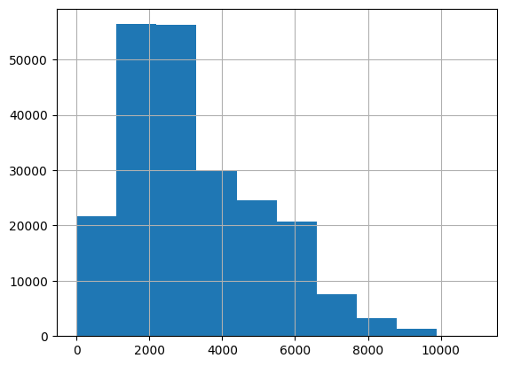

```python
# analisando as variáveis antes de substituir pela mediana

df['inoffice_days'].hist()
df['inoffice_days'].value_counts()
df['inoffice_days'].isnull().sum()
```

### A seguir realizamos uma sequencia de ajustes, apos analisarmos mais criteriosamente o dataframe. Passamos a aplicar media, mediana e moda para linhas faltantes.

```
1.0     173060
2.0      43383
3.0       4515
4.0        798
5.0        141
6.0         25
8.0          4
9.0          3
7.0          3
11.0         2
10.0         1
15.0         1
13.0         1
14.0         1
Name: ceo_count, dtype: int64
```

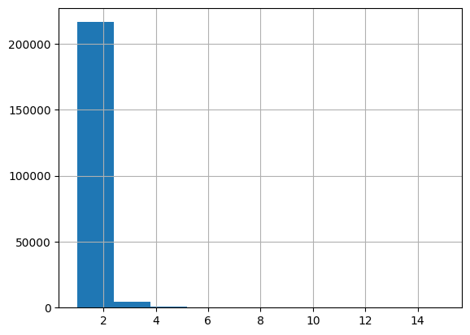

```python
df['ceo_count'].hist()
df['ceo_count'].value_counts()

# variável extremamente concentrada - devemos tratar de alguma outra forma (smote)?
```

```
0.000000         77394
92.592590          453
370.370361         283
185.185181         234
118.518517         234
                 ...
79640.742188         1
106644.453125        1
137125.921875        1
162929.921875        1
263088.875000        1
Name: tang_assets, Length: 55729, dtype: int64
```

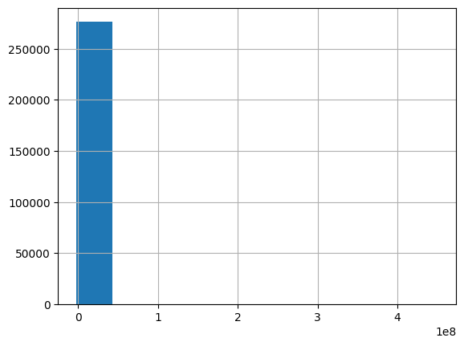

```python
df['tang_assets'].hist()
df['tang_assets'].value_counts()
```

```python
# tranformar missing values em média das colunas 'inoffice_days', 'ceo_count' e 'tang_assets'

median_inoffice_days = df['inoffice_days'].median()
median_ceo_count = df['ceo_count'].median()
median_tang_assets = df['tang_assets'].median()

df['inoffice_days'] = df['inoffice_days'].fillna(median_inoffice_days)
df['ceo_count'] = df['ceo_count'].fillna(median_ceo_count)
df['tang_assets'] = df['tang_assets'].fillna(median_tang_assets)
```

### pela grande concentração de empresas com apenas 1 CEO, iremos substituirs NaNs por 1

#### off por conta da média aplicada

```python
df['ceo_count'].isnull().sum()
```

```
0
```

```python
# substituindo valores negativos por ou NaN por 0
df["subscribed_cap"] = np.where(df["subscribed_cap"] >= 0, df["subscribed_cap"], 0)
df["inventories"] = np.where(df["inventories"] >= 0, df["inventories"], 0)
df["material_exp"] = np.where(df["material_exp"] >= 0, df["material_exp"], 0)
df["personnel_exp"] = np.where(df["personnel_exp"] >= 0, df["personnel_exp"], 0)
```

```python
# substituindo NaNs por median
df['ceo_count'] = np.where(df['ceo_count'].isnull(), median_ceo_count, df['ceo_count'])
```

```python
df['ceo_count'].describe()
```

```
count    278086.00000
mean          1.20006
std           0.47089
min           1.00000
25%           1.00000
50%           1.00000
75%           1.00000
max          15.00000
Name: ceo_count, dtype: float64
```

```python
# como há muitos valores nulos, vamos preencher com a moda

df['gender'] = df['gender'].astype('category')
df['gender'] = np.where(df['gender'].isnull(), df['gender'].mode(), df['gender'])
df['gender'].value_counts()
```

```
male      209843
female     46214
mix        22029
Name: gender, dtype: int64
```

```python
# 'IND2' e 'ORIGIN'
## como há muitos valores nulos, vamos preencher com a moda

mode_ind2 = df['ind2'].mode()[0]
df['ind2'] = df['ind2'].fillna(mode_ind2)
df['ind2'] = df['ind2'].astype(int)
```

```python
df['ind2'].isnull().sum()
# poucos valores faltantes, mas diversas categorias com poucas observações
df['ind2'].value_counts()
# vamos comparar com nace_main
```

```
56    161667
55     32781
28     24830
33     20840
26     14289
       ...
20         6
35         5
88         5
24         4
17         4
Name: ind2, Length: 68, dtype: int64
```

```python
# como há muitos valores nulos, vamos preencher com a moda

df['origin'] = df['origin'].astype('category')
df['origin'].describe()

df['origin'] = np.where(df['origin'].isnull(), df['origin'].mode(), df['origin'])
df['origin'].isnull().sum()
df['origin'].value_counts()
```

```
Domestic    249261
Foreign      22412
mix           6413
Name: origin, dtype: int64
```

```python
df['urban_m'].isnull().sum()
# sem valores faltantes
df['urban_m'] = df['urban_m'].astype('category')
# como interpretar 1, 2 e 3 nos resultados depois seria mais difícil, substituímos as variáveis pelo seu significado
df['urban_m'] = df['urban_m'].replace({1: 'capital', 2: 'city', 3: 'other'})
df['urban_m'].value_counts()
```

```
other      109931
capital     91137
city        77018
Name: urban_m, dtype: int64
```

```python
# poucos valores faltantes em 'region_m', transformado em fator
df['region_m'].isnull().sum()

df['region_m'] = df['region_m'].astype('category')
df['region_m'] = np.where(df['region_m'].isnull(), df['region_m'].mode(), df['region_m'])
print(df['region_m'].isnull().sum())
print(df['region_m'].value_counts())
```

```
0
Central    167878
East        68243
West        41965
Name: region_m, dtype: int64
```

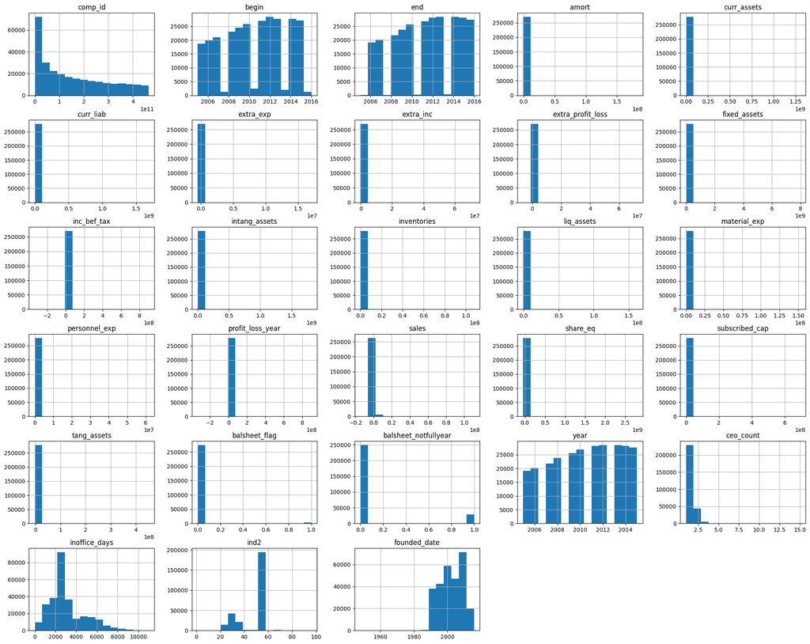

```python
# Qual o tipo de distribuição das variáveis?
# plotar o histograma das variáveis numéricas
df.hist(bins=15, figsize=(25,20));
```

## Alex

#### Utilizando Histogramas para analisar observacoes

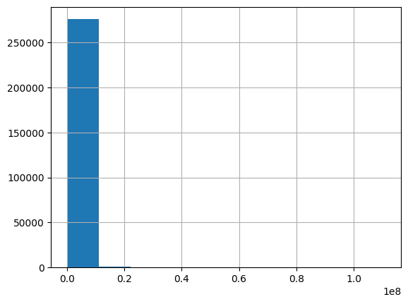

```python
# tratando de sales, como especificado no enunciado
df['sales'] = df['sales'].apply(lambda x: x if x >= 0 else 0)
df['sales'].describe()
df['sales'].hist() #histograma da coluna 'sales'
```

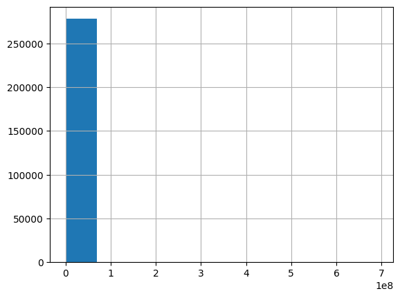

```python
df['subscribed_cap'].isnull().sum()
# pouquíssimos valores faltantes, mas possui valores negativos
df['subscribed_cap'].describe()
# dist da var - redefinir escala para ver melhor
df['subscribed_cap'].hist()
```

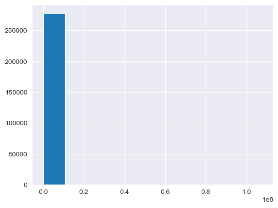

```python
df['inventories'].isnull().sum()
# pouquíssimos valores faltantes, mas possui valores negativos
df['inventories'].describe()
# dist da var - redefinir escala para ver melhor
df['inventories'].hist()
```

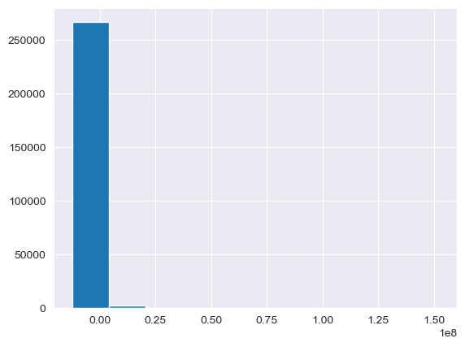

```python
df['material_exp'].isnull().sum()
# alguns valores faltantes, mas possui valores negativos
df['material_exp'].describe()
# dist da var - redefinir escala para ver melhor
df['material_exp'].hist()
```

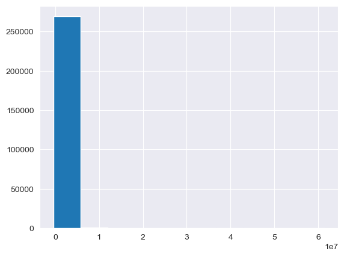

```python
df['personnel_exp'].isnull().sum()
# alguns valores faltantes, mas possui valores negativos
df['personnel_exp'].describe()
# dist da var - redefinir escala para ver melhor
df['personnel_exp'].hist()
```

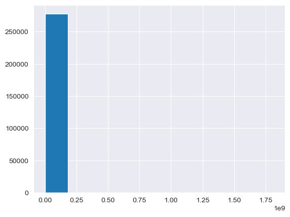

```python
df['intang_assets'].isnull().sum()
# pouquíssimos valores faltantes, mas possui valores negativos
df['intang_assets'].describe()
# dist da var - redefinir escala para ver melhor
df['intang_assets'].hist()
```

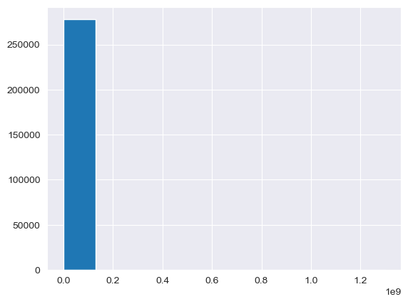

```python
df['curr_assets'].isnull().sum()
# pouquíssimos valores faltantes, mas possui valores negativos
df['curr_assets'].describe()
# dist da var - redefinir escala para ver melhor
df['curr_assets'].hist()
```

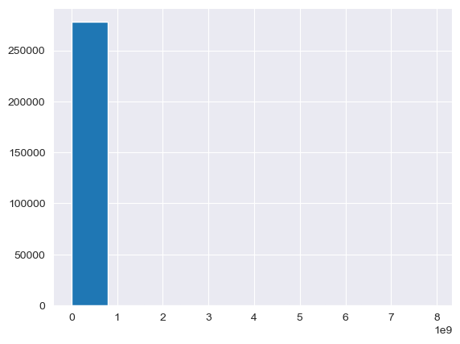

```python
df['fixed_assets'].isnull().sum()
# pouquíssimos valores faltantes, mas possui valores negativos
df['fixed_assets'].describe()
# dist da var - redefinir escala para ver melhor
df['fixed_assets'].hist()
```

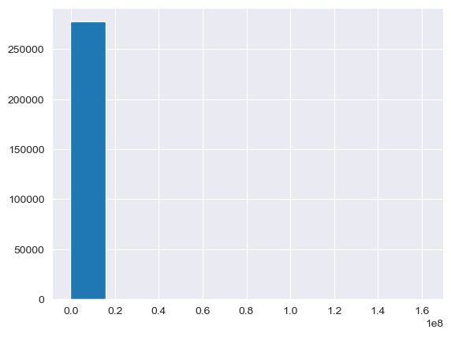

```python
df['liq_assets'].isnull().sum()
# pouquíssimos valores faltantes, mas possui valores negativos
df['liq_assets'].describe()
# dist da var - redefinir escala para ver melhor
df['liq_assets'].hist()
```

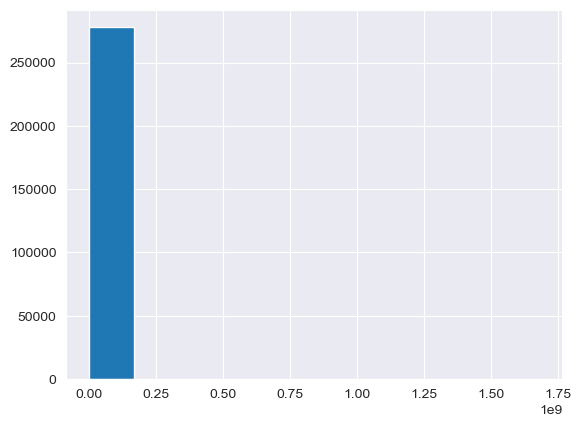

```python
df['curr_liab'].isnull().sum()
# poucos valores faltando, mas possui valores negativos
df['curr_liab'].describe()
# dist da var - redefinir escala para ver melhor
df['curr_liab'].hist()
```

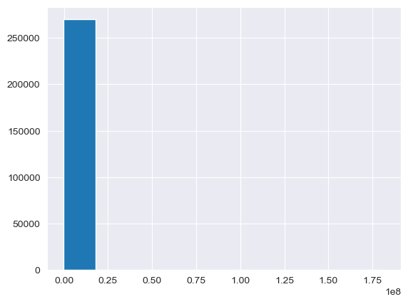

```python
df['amort'].isnull().sum()
# alguns valores faltantes, mas possui valores negativos
df['amort'].describe()
# dist da var - redefinir escala para ver melhor
df['amort'].hist()
```

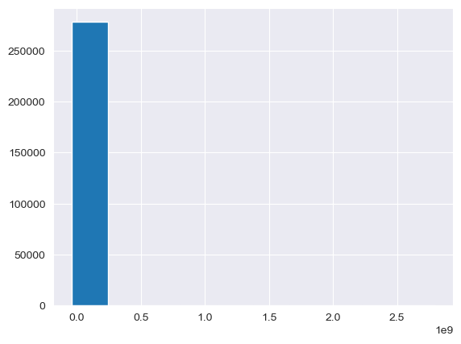

```python
df['share_eq'].isnull().sum()
# poucos valores faltando que serão substituídos pela mediana
df['share_eq'] = np.where(df['share_eq'].isna(), df['share_eq'].median(), df['share_eq'])
df['share_eq'].describe()

# dist da var - redefinir escala para ver melhor
df['share_eq'].hist()
```

```python
# substituindo valores negativos ou NaN por 0

df["intang_assets"] = np.where(df["intang_assets"] >= 0, df["intang_assets"], 0)
df["intang_assets"] = np.where(df["intang_assets"] >= 0, df["intang_assets"], 0)
df["intang_assets"] = np.where(df["intang_assets"] >= 0, df["intang_assets"], 0)


df["intang_assets"] = np.where(df["intang_assets"] >= 0, df["intang_assets"], 0)
df["tang_assets"] = np.where(df["intang_assets"] >= 0, df["intang_assets"], 0)
df["curr_assets"] = np.where(df["curr_assets"] >= 0, df["curr_assets"], 0)
df["fixed_assets"] = np.where(df["fixed_assets"] >= 0, df["fixed_assets"], 0)
df["liq_assets"] = np.where(df["liq_assets"] >= 0, df["liq_assets"], 0)
df['curr_liab'] = np.where(df['curr_liab'] >= 0, df['curr_liab'], 0)
df['amort'] = np.where(df['amort'] >= 0, df['amort'], 0)
```

```python
# garantindo que estamos sem NaNs
df['amort'] = np.where(df['amort'].isna(), df['amort'].median(), df['amort'])
df['curr_assets'] = np.where(df['curr_assets'].isna(), df['curr_assets'].median(), df['curr_assets'])
df['curr_liab'] = np.where(df['curr_liab'].isna(), df['curr_liab'].median(), df['curr_liab'])
df['fixed_assets'] = np.where(df['fixed_assets'].isna(), df['fixed_assets'].median(), df['fixed_assets'])
df['intang_assets'] = np.where(df['intang_assets'].isna(), df['intang_assets'].median(), df['intang_assets'])
df['inventories'] = np.where(df['inventories'].isna(), df['inventories'].median(), df['inventories'])
df['liq_assets'] = np.where(df['liq_assets'].isna(), df['liq_assets'].median(), df['liq_assets'])
df['material_exp'] = np.where(df['material_exp'].isna(), df['material_exp'].median(), df['material_exp'])
df['personnel_exp'] = np.where(df['personnel_exp'].isna(), df['personnel_exp'].median(), df['personnel_exp'])
df['subscribed_cap'] = np.where(df['subscribed_cap'].isna(), df['subscribed_cap'].median(), df['subscribed_cap'])
```

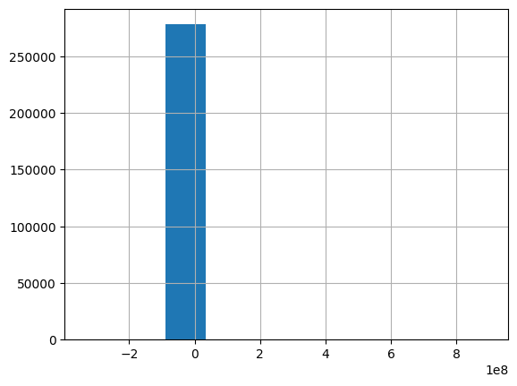

```python
df['inc_bef_tax'].isnull().sum()
# alguns valores faltantes, mas possui valores negativos, então substituiremos por mediana ao invés de média
df['inc_bef_tax'].value_counts()
df['inc_bef_tax'] = np.where(df['inc_bef_tax'].isna(), df['inc_bef_tax'].median(), df['inc_bef_tax'])
df['inc_bef_tax'].describe()
# dist da var - redefinir escala para ver melhor
df['inc_bef_tax'].hist()
```

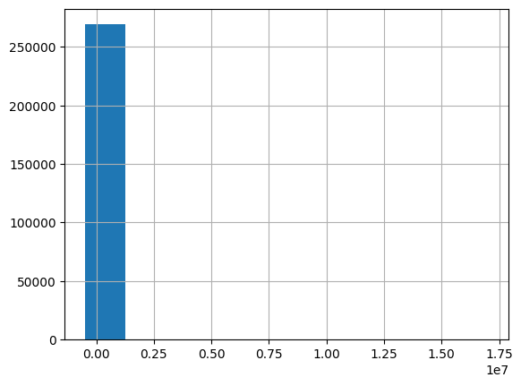

```python
df['extra_exp'].isnull().sum()
# há alguns valores faltantes que serão substituídos pela mediana
df['extra_exp'].describe()
# dist da var - redefinir escala para ver melhor
df['extra_exp'].hist()
df['extra_exp'] = np.where(df['extra_exp'].isna(), df['extra_exp'].median(), df['extra_exp'])
```

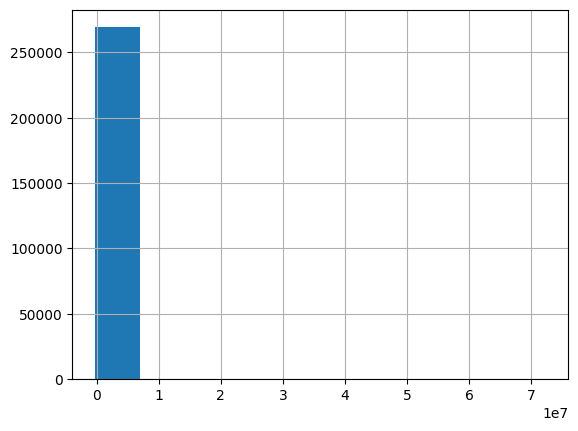

```python
df['extra_inc'].isnull().sum()
# há alguns valores faltantes, que serão substituídos pela mediana
df['extra_inc'].describe()
# dist da var - redefinir escala para ver melhor
df['extra_inc'].hist()
df['extra_inc'] = np.where(df['extra_inc'].isna(), df['extra_inc'].median(), df['extra_inc'])
```

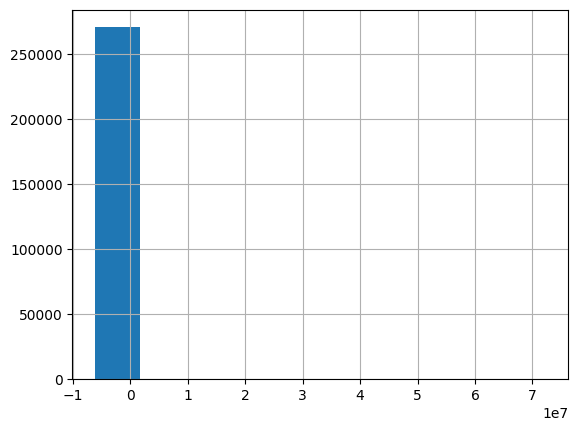

```python
df['extra_profit_loss'].isnull().sum()
# há alguns valores faltantes, que serão substituídos pela mediana
df['extra_profit_loss'].describe()
# dist da var - redefinir escala para ver melhor
df['extra_profit_loss'].hist()
df['extra_profit_loss'] = np.where(df['extra_profit_loss'].isna(), df['extra_profit_loss'].median(), df['extra_profit_loss'])
```

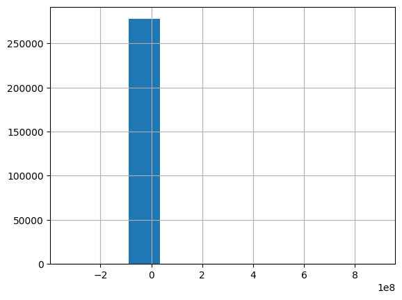

```python
df['profit_loss_year'].isnull().sum()
# há pouquíssimos valores faltantes
df['profit_loss_year'].describe()
# valores faltantes serão substituídos pela mediana
df['profit_loss_year'].hist()
df['profit_loss_year'] = np.where(df['profit_loss_year'].isna(), df['profit_loss_year'].median(), df['profit_loss_year'])
```

```python
# ao retirarmos as observações das empresas nos anos em que não houve balanço completo, perdemos 28.848 observações
df = df[df['balsheet_notfullyear'] != 1]
df.shape[0]
```

```
249238
```

```python
# calculando a idade das empresas que possuem um balanço com pelo menos 1 ano de contabilização
df['tempo_ativa'] = np.where((df['year'] - df['founded_date']) < 0, 0, (df['year'] - df['founded_date']))
df['tempo_ativa'].value_counts()
```

```
1.0     22406
2.0     20651
3.0     18290
4.0     16319
5.0     14467
6.0     12936
7.0     11840
8.0     11246
9.0     11192
10.0    10910
11.0    10647
12.0    10511
13.0    10124
14.0    10003
15.0     9629
16.0     8694
17.0     7769
18.0     6788
19.0     5732
20.0     4552
21.0     3809
22.0     3023
0.0      2553
23.0     2254
24.0     1607
25.0      823
26.0      276
27.0       30
28.0       17
29.0       13
30.0       10
31.0        7
57.0        7
56.0        6
59.0        6
58.0        6
60.0        5
32.0        5
63.0        4
62.0        4
61.0        4
55.0        4
54.0        3
34.0        2
33.0        2
53.0        1
35.0        1
64.0        1
37.0        1
48.0        1
49.0        1
50.0        1
51.0        1
52.0        1
67.0        1
Name: tempo_ativa, dtype: int64
```

```python
# drop de coluna founded_date para não afetar data xx no modelo
## dropada depois de ser criado calculo de 'tempo_ativa'

df = df.drop(['founded_date'], axis=1)
```

```python
# Transforma todos os missings de 'tempo_ativa' em median

median_tempo_ativa = df['tempo_ativa'].median()
df['tempo_ativa'] = df['tempo_ativa'].fillna(median_tempo_ativa)
```

```python
# definindo o marco de "sem receita em ano t"
df['sem_sales'] = (df['sales'] == 0).astype(int) # criamos uma nova coluna que identifica todas as empresas sem receita ou receita negativa no ano da observação, convertendo o booleano do condicional para inteiro
df['sem_sales'].sum() #contando o número de observações em que a empresa não teve receita identificada ou negativa
```

```
37303
```

```python
df2 = df.sort_values(by=['comp_id', 'year'])
```

```python
df2['falira'] = (
        (df2['sem_sales'] == 0)
        & (df2.groupby('comp_id')['sem_sales'].shift(-2) == 1)
        | (df2['sem_sales'] == 1)
        & (df2.groupby('comp_id')['sem_sales'].shift(1) == 1)).astype(int)

df2['falira'].sum()
```

```
33507
```

```python
df3 = df.sort_values(by=['comp_id', 'year'])
```

```python
df3['falira'] = (
        (df3['sem_sales'] == 0)
        & (df3.groupby('comp_id')['sem_sales'].shift(-2) == 1)
        & (df3.groupby('comp_id')['sem_sales'].shift(-1) == 1)
        | (df3['sem_sales'] == 1)
        & (df3.groupby('comp_id')['sem_sales'].shift(1) == 1)).astype(int)
# cria uma nova coluna que cria uma máscara para uma empresa que não tem sales em t e não tem receita em t - 2, ou seja, irá falir, transformando o booleano em inteiro depois
df3['falira'].sum()
```

```
27575
```

```python
df2
```

|  | comp_id | begin | end | amort | curr_assets | curr_liab | extra_exp | extra_inc | extra_profit_loss | fixed_assets | ... | ceo_count | inoffice_days | gender | origin | ind2 | urban_m | region_m | tempo_ativa | sem_sales | falira |
| --- | --- | --- | --- | --- | --- | --- | --- | --- | --- | --- | --- | --- | --- | --- | --- | --- | --- | --- | --- | --- | --- |
| 0 | 1.001034e+06 | 2005-01-01 | 2005-12-31 | 692.592590 | 7266.666504 | 7574.074219 | 0.0 | 0.0 | 0.0 | 1229.629639 | ... | 2.0 | 5686.5 | mix | Domestic | 56 | capital | Central | 15.0 | 0 | 0 |
| 1 | 1.001034e+06 | 2006-01-01 | 2006-12-31 | 603.703674 | 13122.222656 | 12211.111328 | 0.0 | 0.0 | 0.0 | 725.925903 | ... | 2.0 | 5686.5 | mix | Domestic | 56 | capital | Central | 16.0 | 0 | 0 |
| 2 | 1.001034e+06 | 2007-01-01 | 2007-12-31 | 425.925934 | 8196.295898 | 7800.000000 | 0.0 | 0.0 | 0.0 | 1322.222168 | ... | 2.0 | 5686.5 | mix | Domestic | 56 | capital | Central | 17.0 | 0 | 0 |
| 3 | 1.001034e+06 | 2008-01-01 | 2008-12-31 | 300.000000 | 8485.185547 | 7781.481445 | 0.0 | 0.0 | 0.0 | 1022.222229 | ... | 2.0 | 5686.5 | mix | Domestic | 56 | capital | Central | 18.0 | 0 | 0 |
| 4 | 1.001034e+06 | 2009-01-01 | 2009-12-31 | 207.407410 | 5137.037109 | 15300.000000 | 0.0 | 0.0 | 0.0 | 814.814819 | ... | 2.0 | 5686.5 | mix | Domestic | 56 | capital | Central | 19.0 | 0 | 1 |
| ... | ... | ... | ... | ... | ... | ... | ... | ... | ... | ... | ... | ... | ... | ... | ... | ... | ... | ... | ... | ... | ... |
| 287824 | 4.641209e+11 | 2011-01-01 | 2011-12-31 | 0.000000 | 1807.407349 | 3.703704 | 0.0 | 0.0 | 0.0 | 0.000000 | ... | 1.0 | 8187.0 | female | Domestic | 55 | city | East | 21.0 | 0 | 1 |
| 287825 | 4.641209e+11 | 2012-01-01 | 2012-12-31 | 0.000000 | 1518.518555 | 96.296295 | 0.0 | 0.0 | 0.0 | 0.000000 | ... | 1.0 | 8187.0 | female | Domestic | 55 | city | East | 22.0 | 1 | 0 |
| 287826 | 4.641209e+11 | 2013-01-01 | 2013-12-31 | 0.000000 | 988.888916 | 77.777779 | 0.0 | 0.0 | 0.0 | 0.000000 | ... | 1.0 | 2859.0 | male | Domestic | 55 | city | East | 23.0 | 1 | 1 |
| 287827 | 4.641209e+11 | 2014-01-01 | 2014-12-31 | 0.000000 | 644.444458 | 233.333328 | 0.0 | 0.0 | 0.0 | 0.000000 | ... | 1.0 | 1441.0 | female | Domestic | 55 | city | East | 24.0 | 1 | 1 |
| 287828 | 4.641209e+11 | 2015-01-01 | 2015-12-31 | 0.000000 | 166.666672 | 270.370361 | 0.0 | 0.0 | 0.0 | 0.000000 | ... | 1.0 | 1441.0 | female | Domestic | 55 | city | East | 25.0 | 1 | 1 |

249238 rows × 34 columns

```python
missing_values = (df.isnull().sum() / df.shape[0]).sort_values(ascending=False)
print("Percentage de missing em cada coluna:")
print(missing_values)
print("Total de numeros das linhas:", df.shape[0])
```

```
Percentage de missing em cada coluna:
share_eq                0.000349
comp_id                 0.000000
sales                   0.000000
tempo_ativa             0.000000
region_m                0.000000
urban_m                 0.000000
ind2                    0.000000
origin                  0.000000
gender                  0.000000
inoffice_days           0.000000
ceo_count               0.000000
year                    0.000000
balsheet_notfullyear    0.000000
balsheet_flag           0.000000
tang_assets             0.000000
subscribed_cap          0.000000
profit_loss_year        0.000000
begin                   0.000000
personnel_exp           0.000000
material_exp            0.000000
liq_assets              0.000000
inventories             0.000000
intang_assets           0.000000
inc_bef_tax             0.000000
fixed_assets            0.000000
extra_profit_loss       0.000000
extra_inc               0.000000
extra_exp               0.000000
curr_liab               0.000000
curr_assets             0.000000
amort                   0.000000
end                     0.000000
sem_sales               0.000000
dtype: float64
Total de numeros das linhas: 249238
```

```python
df['sem_sales'].describe()
```

```
count    249238.000000
mean          0.149668
std           0.356747
min           0.000000
25%           0.000000
50%           0.000000
75%           0.000000
max           1.000000
Name: sem_sales, dtype: float64
```

```python
df2 = df2.drop(['begin', 'end'], axis=1)
```

```python
df3 = df3.drop(['begin', 'end'], axis=1)
```

```python
print("# Registros:\t{}".format(df2.shape[0]))
print("# Variáveis:\t{}\n".format(df2.shape[1]))

#Quais os tipos das variáveis?
display(df2.dtypes)
```

```
# Registros:	249238
# Variáveis:	32
```

```
comp_id                  float64
amort                    float64
curr_assets              float64
curr_liab                float64
extra_exp                float64
extra_inc                float64
extra_profit_loss        float64
fixed_assets             float64
inc_bef_tax              float64
intang_assets            float64
inventories              float64
liq_assets               float64
material_exp             float64
personnel_exp            float64
profit_loss_year         float64
sales                    float64
share_eq                 float64
subscribed_cap           float64
tang_assets              float64
balsheet_flag              int64
balsheet_notfullyear       int32
year                       int64
ceo_count                float64
inoffice_days            float64
gender                    object
origin                    object
ind2                       int32
urban_m                 category
region_m                  object
tempo_ativa              float64
sem_sales                  int32
falira                     int32
dtype: object
```

#### Filtrando apenas `year` 2012

### Year == 2012

#### empresas que possuem receita abaixo de 10MI e acima de 1k Euros

```python
df4 = df2.query("sales <= 10000000 & sales >= 1000")
df4 = df4.query("year==2012")
df4 = df4.drop(['balsheet_flag','balsheet_notfullyear', 'sem_sales'], axis=1)
df4.shape[0]
```

```
20159
```

```python
df5 = df3.query("sales <= 10000000 & sales >= 1000")
df5 = df5.query("year==2012")
df5 = df5.drop(['balsheet_flag','balsheet_notfullyear', 'sem_sales'], axis=1)
df5.shape[0]
```

```
20159
```

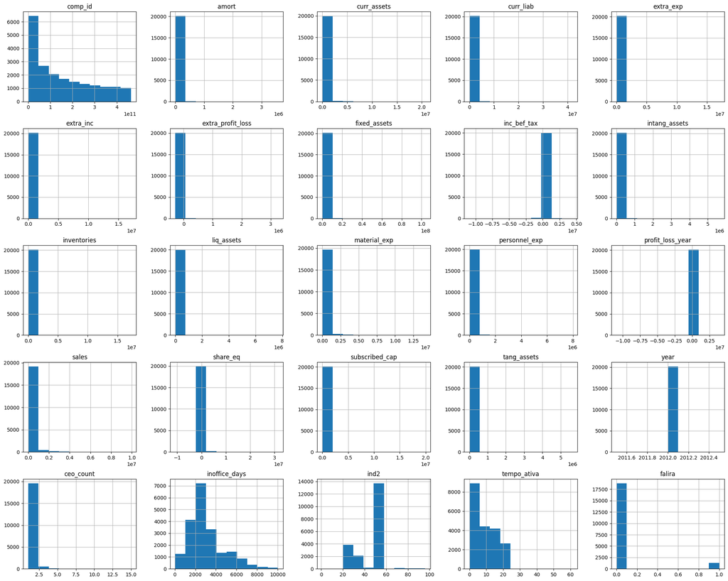

```python
df4.hist(bins=10, figsize=(25,20));
```

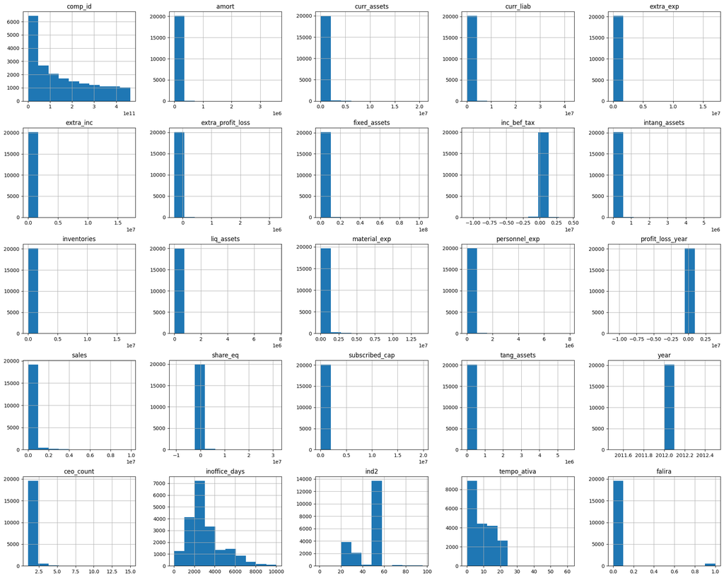

```python
df5.hist(bins=10, figsize=(25,20));
```

```python
x_vars = list(df4.columns)
x_vars.remove('sales')

sns.pairplot(data=df4, y_vars=['sales'], x_vars=x_vars)
sns.set(rc={'figure.figsize':(25,20)})
```

[output not shown]

```python
x_vars2 = list(df5.columns)
x_vars2.remove('sales')

sns.pairplot(data=df5, y_vars=['sales'], x_vars=x_vars2)
sns.set(rc={'figure.figsize':(25,20)})
```

[figure not shown]

## Correlação entre as Variáveis

```python
corr = df4.corr()
corr2 = df5.corr()
```

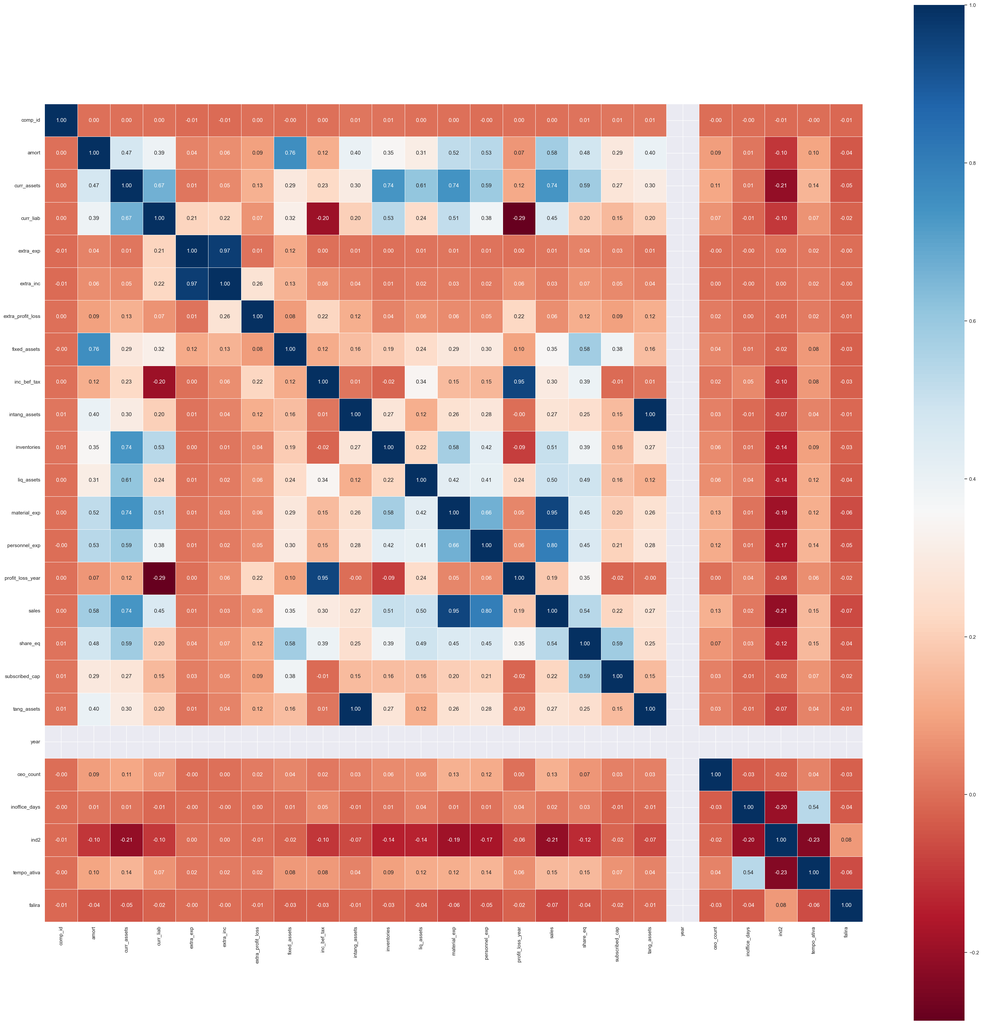

```python
# plotar um heatmap a partir das correlações

fig, ax = plt.subplots(figsize=(40,40))         # Sample figsize in inches
sns.heatmap(corr, cmap='RdBu', fmt='.2f', square=True, linecolor='white', annot=True, linewidths=.5, ax=ax)
```

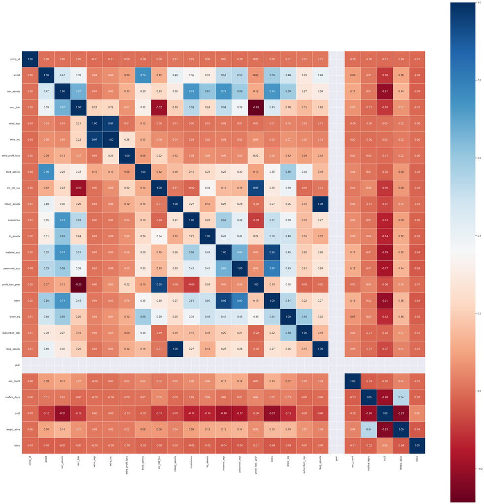

```python
# plotar um heatmap a partir das correlações
fig, ax = plt.subplots(figsize=(40,40))         # Sample figsize in inches
sns.heatmap(corr2, cmap='RdBu', fmt='.2f', square=True, linecolor='white', annot=True, linewidths=.5, ax=ax)
```

```python
#Assim, para identificarmos as variáveis correlacionadas, usamos um laço for:

p = 0.75 # correlação mínima
var = []
for i in corr.columns:
    for j in corr.columns:
        if(i != j):
            if np.abs(corr[i][j]) > p: # se maior do que |p|
                var.append([i,j])
print('Variáveis mais correlacionadas:\n', var)

#Com isso, podemos remover as variáveis mais correlacionadas de modo a reduzir a redundância nos dados.
```

[output not shown]

```python
# visualizando em tabela os resultados de coeficiente - feita só para df4 porque possui basicamente as mesmas relações entre variáveis que df5
df_corr = df4.copy()
df_corr = pd.DataFrame(var, columns=['Var 1', 'Var 2'])
df_corr['Coeficiente de correlacao'] = [np.abs(corr.loc[df_corr.loc[i,'Var 1'], df_corr.loc[i,'Var 2']]) for i in df_corr.index]
df_corr = df_corr.sort_values(by='Coeficiente de correlacao', ascending=False).reset_index(drop=True)

# Display novo dataframe
print(df_corr.to_string(index=False))
```

```
           Var 1            Var 2  Coeficiente de correlacao
   intang_assets      tang_assets                   1.000000
     tang_assets    intang_assets                   1.000000
       extra_exp        extra_inc                   0.967144
       extra_inc        extra_exp                   0.967144
    material_exp            sales                   0.949661
           sales     material_exp                   0.949661
     inc_bef_tax profit_loss_year                   0.946524
profit_loss_year      inc_bef_tax                   0.946524
   personnel_exp            sales                   0.799822
           sales    personnel_exp                   0.799822
           amort     fixed_assets                   0.758188
    fixed_assets            amort                   0.758188
```

## Exportar dataframe para R

```python
df2.to_csv(r'C:/Users/jeffersonlbr/Documents/PADS Insper/PROJETO INTEGRADOR/bisnode_prep_2012.csv', index=False)
```